# ZywOo vs s1mple

# A Statistical Analysis of the Best CSGO Players

By Shenzhi Shi

## Introduction

Counter-Strike: Global Offensive (CSGO) is a popular multiplayer first-person shooter game with a widespread esports scene. The game consists of two opposing five person teams, one attacking ("terrorists") and one defending ("counter-terrorists") specified locations (bomb sites). The goal of the terrorists is to plant a bomb onto one of the bomb sites. The goal of the counter-terrorists is to either defend the bomb sites until the round ends, or to successfully defuse the bomb after it has been planted.  
As with most popular competitive sports, there has been much debate on which players are at the very top. This analysis hopes to shed some light on this question by analyzing player statistics in past professional CSGO matches.

## Getting Data

We downloaded our data from https://www.kaggle.com/mateusdmachado/csgo-professional-matches.  
This data was scraped from https://www.hltv.org/, a widely accepted source for CSGO statistics.

```python
import pandas as pd
import numpy as np
import statsmodels.api as sm
import matplotlib.pyplot as plt
import seaborn as sns
import warnings
warnings.filterwarnings('ignore')
```

```python
#import our dataset
players = pd.read_csv("players.csv")
results = pd.read_csv("results.csv")
```

## Data Manipulation

Our dataset includes many lesser known teams. We want to analyze the best of the best, so we will only be looking at the top 20 teams as of 2020 according to HLTV.  
We want to examine how well each player did in each game, so we will create a new dataset using the players dataset and the results dataset.  
This new dataset should include the year the game was played (year), the map the game was played on (map), how well that player played overall (rating), how well that player played on each side (rating_t and rating_ct), and if they won the game (win). The ratings are HLTV ratings which represents how well a player plays per round based on kills, assists, contribution, etc.  
Switching teams happens relatively often in pro CS:GO, so we will only be considering individual player statistics and not team statistics.

```python
#teams we want to look at
top_20 = ['Astralis', 'mousesports', 'Liquid', 'fnatic', 'Evil Geniuses', 'Natus Vincere', 'Vitality',
          'G2', 'FaZe', '100 Thieves', 'MAD Lions', 'NiP', 'forZe', 'Heroic', 'FURIA', 'OG', 'ENCE',
          'MIBR', 'Virtus.pro', 'GODSENT']
players = players[players['team'].isin(top_20)]
results = results[results['team_1'].isin(top_20)]
results = results[results['team_2'].isin(top_20)]

#return (rating, rating_t, rating_ct) based on map
def get_ratings(m, player):
    if player['map_1'] == m:
        return player['m1_rating'], player['m1_rating_t'], player['m1_rating_ct']
    elif game['map_2'] == m:
        return player['m2_rating'], player['m2_rating_t'], player['m2_rating_ct']
    else:
        return player['m3_rating'], player['m3_rating_t'], player['m3_rating_ct']

#create new dataset of player stats on each map
df = []
for _, match in results.iterrows():
    m = match['_map']
    p = players[players['match_id'] == match['match_id']]
    #separate year from the date value
    year = match['date'].split('-')[0]
    #get individual player data for team1
    p1 = p[p['team'] == match['team_1']]
    win = 1 if match['map_winner'] == 1 else 0
    for _, player in p1.iterrows():
        p_name = player['player_name']
        rating, rating_t, rating_ct = get_ratings(m, player)
        df.append({'year':year, 'player':p_name, 'map':m, 'rating':rating,
                   'rating_t':rating_t, 'rating_ct':rating_ct, 'win':win})
    #get individual player data for team2
    p2 = p[p['team'] == match['team_2']]
    win = 1 if match['map_winner'] == 2 else 0
    for _, player in p2.iterrows():
        p_name = player['player_name']
        rating, rating_t, rating_ct = get_ratings(m, player)
        df.append({'year':year, 'player':p_name, 'map':m, 'rating':rating,
                   'rating_t':rating_t, 'rating_ct':rating_ct, 'win':win})
df = pd.DataFrame(df)
df
```

|  | year | player | map | rating | rating_t | rating_ct | win |
| --- | --- | --- | --- | --- | --- | --- | --- |
| 0 | 2020 | AdreN | Vertigo | 0.78 | 1.03 | 0.51 | 1 |
| 1 | 2020 | Jame | Vertigo | 1.04 | 1.21 | 0.86 | 1 |
| 2 | 2020 | SANJI | Vertigo | 1.20 | 1.86 | 0.49 | 1 |
| 3 | 2020 | buster | Vertigo | 1.06 | 1.26 | 0.85 | 1 |
| 4 | 2020 | qikert | Vertigo | 1.36 | 2.08 | 0.58 | 1 |
| ... | ... | ... | ... | ... | ... | ... | ... |
| 26080 | 2015 | NiKo | Mirage | 1.40 | NaN | NaN | 1 |
| 26081 | 2015 | chrisJ | Mirage | 1.51 | NaN | NaN | 1 |
| 26082 | 2015 | denis | Mirage | 0.82 | NaN | NaN | 1 |
| 26083 | 2015 | gob b | Mirage | 0.91 | NaN | NaN | 1 |
| 26084 | 2015 | nex | Mirage | 1.15 | NaN | NaN | 1 |

26085 rows × 7 columns

Now that we have all the data we want to examine, let's drop all rows with missing values.

```python
df = df.dropna()
df
```

|  | year | player | map | rating | rating_t | rating_ct | win |
| --- | --- | --- | --- | --- | --- | --- | --- |
| 0 | 2020 | AdreN | Vertigo | 0.78 | 1.03 | 0.51 | 1 |
| 1 | 2020 | Jame | Vertigo | 1.04 | 1.21 | 0.86 | 1 |
| 2 | 2020 | SANJI | Vertigo | 1.20 | 1.86 | 0.49 | 1 |
| 3 | 2020 | buster | Vertigo | 1.06 | 1.26 | 0.85 | 1 |
| 4 | 2020 | qikert | Vertigo | 1.36 | 2.08 | 0.58 | 1 |
| ... | ... | ... | ... | ... | ... | ... | ... |
| 25602 | 2016 | Maikelele | Dust2 | 0.66 | 0.57 | 0.74 | 0 |
| 25603 | 2016 | aizy | Dust2 | 1.10 | 1.03 | 1.17 | 0 |
| 25604 | 2016 | fox | Dust2 | 1.32 | 1.37 | 1.28 | 0 |
| 25605 | 2016 | jkaem | Dust2 | 1.30 | 0.88 | 1.72 | 0 |
| 25606 | 2016 | rain | Dust2 | 0.79 | 0.38 | 1.20 | 0 |

21917 rows × 7 columns

Finally, we will consolidate the data by getting the average ratings and win percentage of each player on each map.  
Let's ignore data from players who've played less than 10 games on a map so we can have more accurate winrates and avoid outliers.

```python
data = []
for p in df['player'].unique():
    for m in df[df['player']==p]['map'].unique():
        d = df[((df['map']==m)&(df['player']==p))]
        if d.shape[0] >= 10:
            avg_rating = np.mean(d['rating'])
            avg_rating_t = np.mean(d['rating_t'])
            avg_rating_ct = np.mean(d['rating_ct'])
            win_rate = np.mean(d['win'])
            data.append({'player':p, 'map':m, 'avg_rating':avg_rating,
                         'avg_rating_t':avg_rating_t, 'avg_rating_ct':avg_rating_ct, 'win_rate':win_rate})
data = pd.DataFrame(data)
data
```

|  | player | map | avg_rating | avg_rating_t | avg_rating_ct | win_rate |
| --- | --- | --- | --- | --- | --- | --- |
| 0 | AmaNEk | Dust2 | 1.031600 | 1.060400 | 1.040400 | 0.640000 |
| 1 | AmaNEk | Inferno | 0.955000 | 0.928333 | 0.996667 | 0.333333 |
| 2 | AmaNEk | Nuke | 1.073889 | 1.077778 | 1.082222 | 0.666667 |
| 3 | AmaNEk | Train | 1.101538 | 0.911538 | 1.220000 | 0.538462 |
| 4 | AmaNEk | Overpass | 1.031333 | 1.134667 | 0.942000 | 0.333333 |
| ... | ... | ... | ... | ... | ... | ... |
| 642 | aizy | Train | 1.080000 | 1.060588 | 1.076471 | 0.588235 |
| 643 | wenton | Cache | 1.152727 | 1.215455 | 1.078182 | 0.727273 |
| 644 | nex | Cache | 1.245385 | 1.451538 | 1.108462 | 0.692308 |
| 645 | nex | Dust2 | 1.059231 | 1.159231 | 0.981538 | 0.538462 |
| 646 | fox | Cache | 0.899231 | 1.017692 | 0.782308 | 0.153846 |

647 rows × 6 columns

There are no missing data, so now our final dataset should be:  
**data**  
player: The player's in-game name  
map: The map  
avg_rating: The average HLTV rating of the player on that map  
avg_rating_t: The average HLTV rating of the player on that map while on the attacking side  
avg_rating_ct: The average HLTV rating of the player on that map while on the defending side  
win_rate: The win rate of the player on that map

## Data Visualization and Analysis

Now let's try to visualize the data and gain some insight on which players sit at the very top in terms of skill.  
We will start by plotting overall rating vs overall win rate for each map. The top players in recent years have been ZywOo and s1mple.

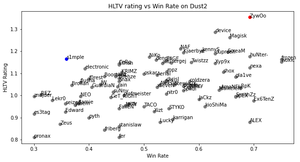

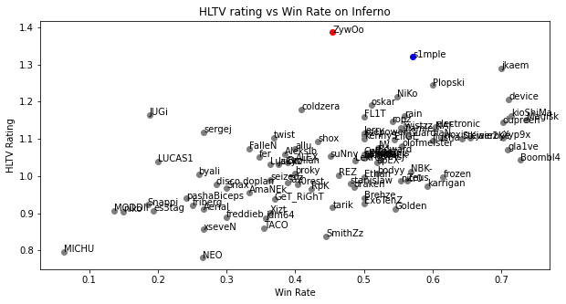

[figure not shown]

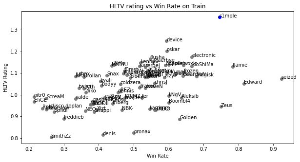

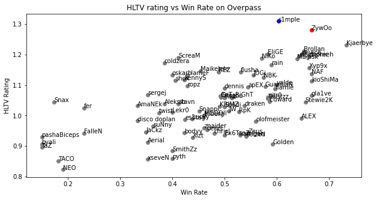

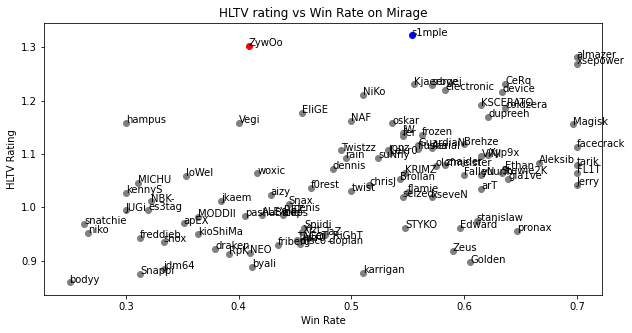

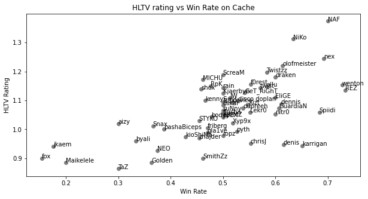

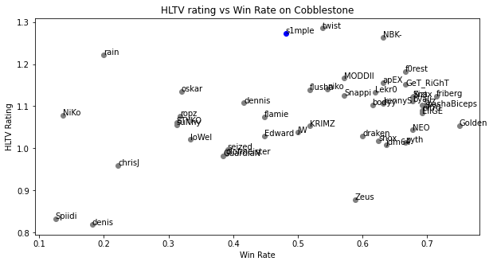

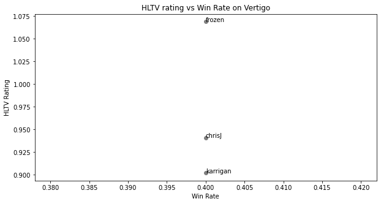

```python
maps = data['map'].unique()

#plot every player
for _, m in enumerate(maps):
    plt.subplots(figsize=(10,5))
    for _, point in data[(data['map']==m)].iterrows():
        x, y = (point['win_rate'], point['avg_rating'])
        if point['player'] == 'ZywOo':
            plt.scatter(x,y,color='r')
        elif point['player'] == 's1mple':
            plt.scatter(x,y,color='b')
        else:
            plt.scatter(x,y,color='gray')
        plt.annotate(point['player'], (x, y))
    plt.xlabel("Win Rate")
    plt.ylabel("HLTV Rating")
    plt.title("HLTV rating vs Win Rate on "+m)
    plt.show()
```

As far as HLTV rating goes, these players are in the top for most of the maps that they've played on. ZywOo consistently plays well on the map Dust2, while s1mple dominates on the map Train. They both perform very well on Overpass. However, for winrates, there are many players who beat out s1mple and ZywOo on several maps, such as Magisk on Nuke, and many players on Mirage.

## Conclusions

Overall, it seems that ZywOo and s1mple are pretty evenly matched in terms of individual prowess and technical skill. ZywOo does better on 3 maps compared to s1mple: Nuke, Inferno, and Dust2. s1mple does better on 2 maps: Mirage and Overpass. However, the difference in how well ZywOo performs on the maps that he does better in compared to the maps that s1mple does better in is large. On Mirage and Overpass, ZywOo's HLTV rating is very close to s1mple's, but s1mple lags far behind in HLTV rating on Nuke, Inferno and Dust2.  
Purely in terms of individual skill, ZywOo out performs s1mple. However, CSGO is a team-based game, so this much information is not much for truly determining which player is better since communication and strategy is just as much part of the game as the amount of kills a player gets.  
For more in depth analysis on which player is better at CSGO, we could opt to look at their performance compared to their teammates, or even gather additional data such as positioning in game to see how well they play around their teammates and even enemies.  
For more information on data manipulation:  
https://medium.com/analytics-vidhya/python-data-manipulation-fb86d0cdd028  
https://pandas.pydata.org/docs/  
For more information on the CSGO esports scene:  
https://pro.eslgaming.com/csgo/proleague/teams/  
https://www.hltv.org/stats  
For more information on CSGO itself:  
https://store.steampowered.com/app/730/CounterStrike_Global_Offensive/  
https://www.youtube.com/watch?v=-J-A8CUFA-c&ab_channel=NEONisticTVNEONisticTV